# Australia Fantasy Report

## Introduction

G'day managers old and new, and welcome back to the Ahead At The Apex fantasy league for 2026. This, if you can believe it is our 8th year running and we are starting somewhat on the back foot. Due to Josh taking a break over winter, the code is in a right state, so we are as we were at the end of last year, no new improvements to mention yet going into the 2026 season. But there are plenty to come that's for sure, new stats, new tracking, new plotting, and so on and so on, so stay tuned. This year too, we promise not to disappear while these improvements are being made, we'll run a second environment to test these things in.

For those who might be new to all of this, here's how it will work. Each race week you will be able to make changes to your team, there may even be recommendations in the new Patreon space over at patreon.com/c/aatapex. Then, the race happens and your teams score points. Then the following week, we process the data, produce some lovely figures, and write a report. In that time, we may also write reviews, stories, and speculation articles over on the website and discuss these in depth over on the podcast.

As for the fantasy league, prizes are awarded to those who are competing, pride is awarded to those who are not, and by the end of the season we will have our winners and losers. We are also running an F1 Play league for pride. Check the Facebook page for details on this one. The driver/constructor points are taken post-race, with their values taken pre-race (i.e., as if you were buying them for that race). Manager teams are predicted and have their lineups corrected when predicted scores don't match the real scores, it's a lot to try and keep on top of 60 teams.

## Fantasy League Scores

Scores for drivers/constructors in the current year's fantasy league, along with manager/team points, values, and statistics. Note: driver and constructor values are taken as the cost to enter the current race and are updated the week before the race.

## Lineup Scores

Max Verstappen may not like the new regulations but he leads the way this week with a top score of 50 points thanks to his progression through the field. George Russell is in second place with 39 points ahead of teammate Kimi Antonelli with 32. Then we have Charles Leclerc with 29 points, and rounding out the top five is Lewis Hamilton with 25 points. At the back of the grid we have Lance Stroll with -23 points, followed by Nico Hulkenberg in his first outing for Audi with -20 points. Then we have Valtteri Bottas with -16, Fernando Alonso with -14 (tied with Oscar Piastri), and Isack Hadjar with -8.

Mercedes take first blood this year with a huge 96 points, ahead of Ferrari with 69 points and Red Bull with 42 points in third place. At the back of the field we have Aston Martin with -38 points, behind Cadillac with -13 in their first weekend. Audi round out the bottom three with 0 points from the opening round.

Naturally, the championship standings are exactly as above.

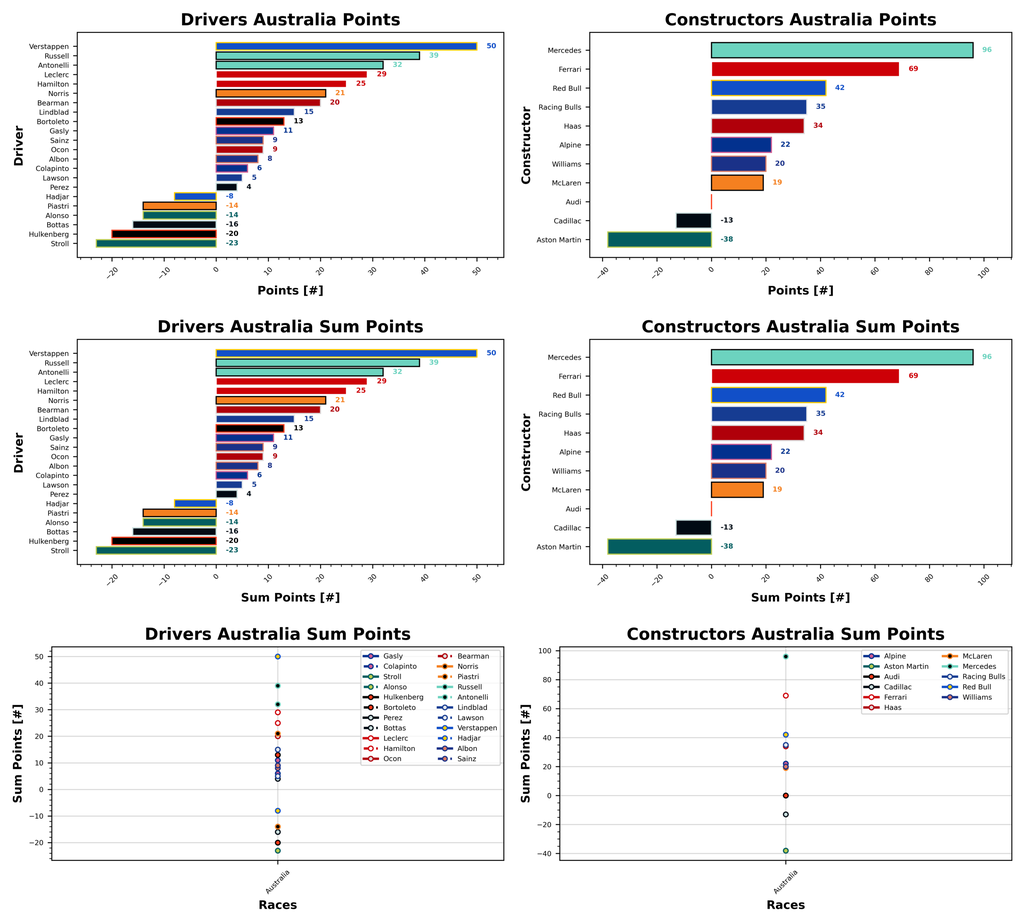

With a price reset over the winter break, it's 4-time champion Max Verstappen who was your most expensive option this week with a value of 27.7, ahead of George Russell as the season favourite at 27.4, and reigning champion Lando Norris at 27.2. Oscar Piastri was next at 25.5, followed by Kimi Antonelli at 23.2. Your cheapest driver was Valtteri Bottas at 5.9, behind teammate Perez at 6.0. Then we have Franco Colapinto at 6.2, tied with Lindblad, and Bortoleto at 6.4. Rounding out the cheap seats is Liam Lawson at 6.5.

Mercedes were your most expensive team this week at 29.3, followed by McLaren at 28.9 and Red Bull at 28.5. Cadillac were your cheapest option at 6.0, followed by Racing Bulls at 6.3 and Audi at 6.6.

All values are in Million Dollars.

Drivers that have already lost their 100% record at the first hurdle: Lance Stroll, Oscar Piastri, Nico Hulkenberg, Isack Hadjar, Valtteri Bottas, and Fernando Alonso. Constructors that have already lost their 100% record: Cadillac, Audi, and Aston Martin.

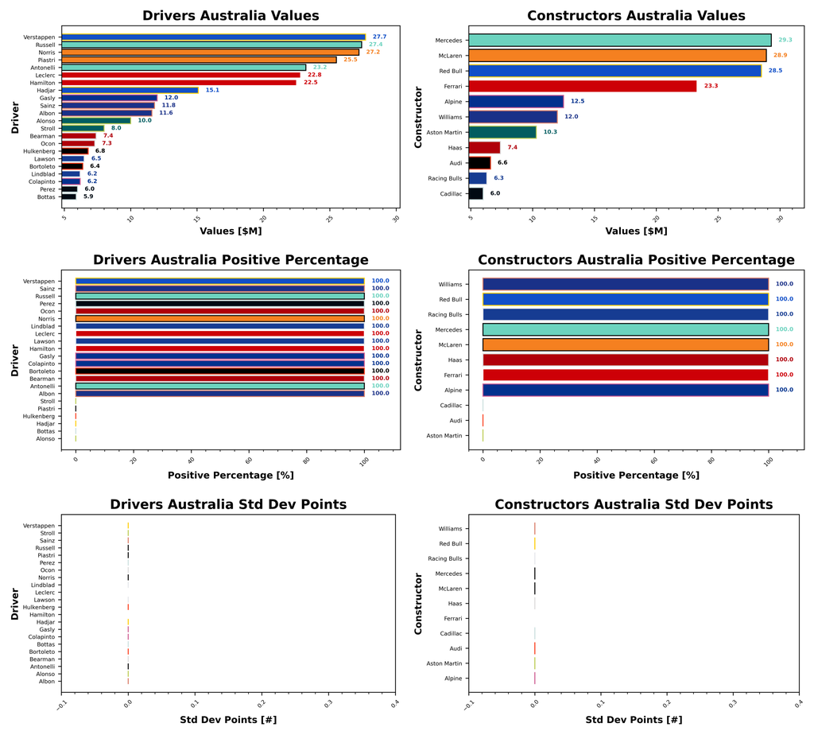

No average statistics after 1 race.

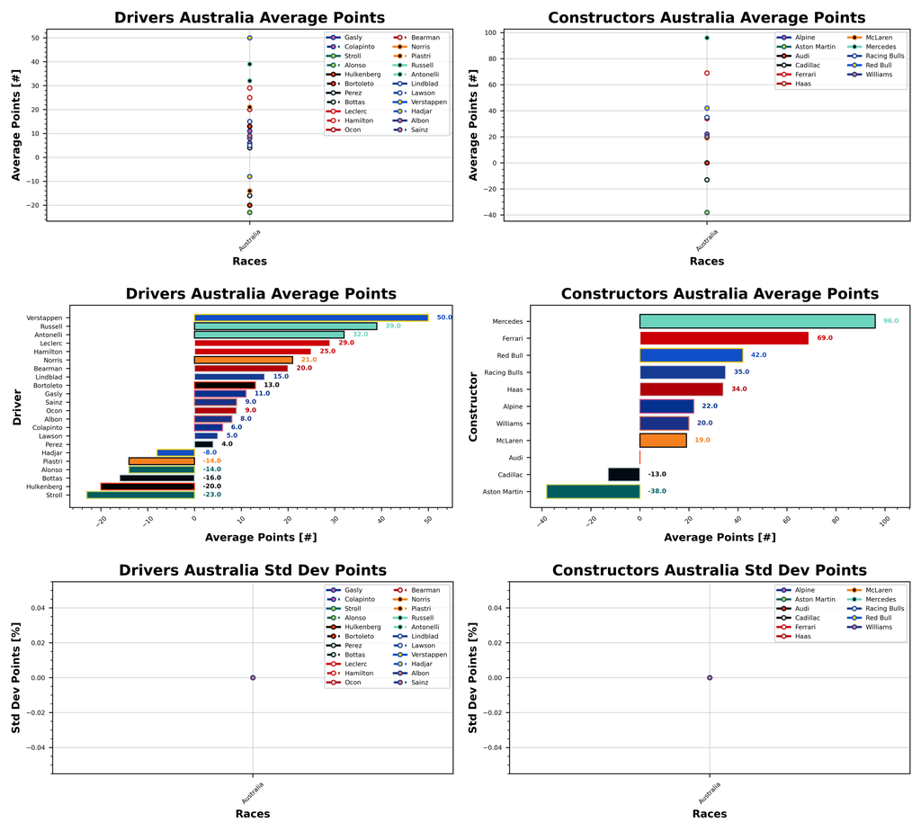

Driver of the week in Australia was Ollie Bearman, who comes in with a points per value of 2.7 ppm, ahead of Arvid Lindblad at 2.42 ppm. They're followed by Bortoleto at 2.03 ppm and Max Verstappen at 1.81 ppm. Race winner George Russell rounds out the top five with 1.42 ppm. At the bottom of the table, Nico Hulkenberg was your worst driver of the week with a points per value of -2.94 ppm, ahead of Lance Stroll with -2.88 ppm and Bottas with -2.71 ppm. Alonso next with -1.4 ppm and Oscar Piastri rounds out the bottom five with -0.55 ppm.

Racing Bulls were your team of the week with a points per value of 5.56 ppm, ahead of Haas with 4.59 ppm and Mercedes with 3.28 ppm. Aston Martin were your worst team of the week with -3.69 ppm, followed by Cadillac with -2.17 ppm and Audi with 0 ppm.

ppm = points per million Dollars.

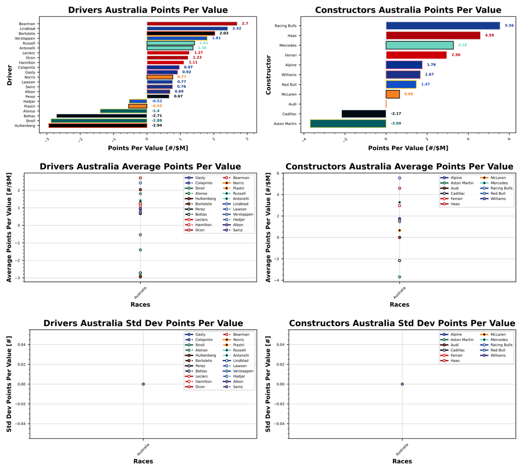

### Manager Scores

Down at the bottom we have Patrick and In Haast Place with -110 points, straight out the gate with a mega negative score. Then we have Will and Pay Drivers with -106 points, followed by Stuart and Tyrell P34 6 Wheel Buggy with -70 points. In fourth place it's Sam and PadCocks with -39 points, followed by Jessica and Emien Rays with -12 points.

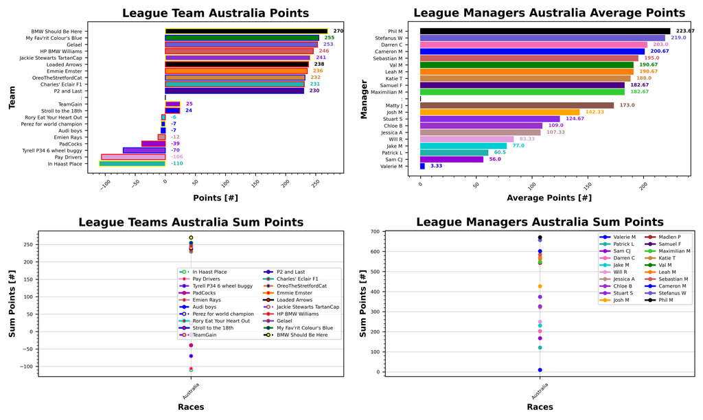

Obviously, the championship standings are as above for the first race of the season.

Similarly, biggest winner and biggest loser are yet to be calculated due to no positions gained or lost.

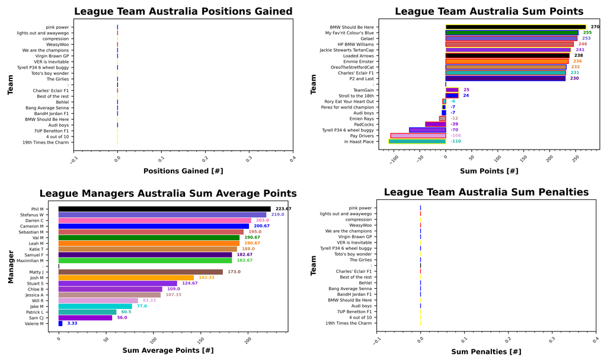

Bearman was your most popular driver this week with 36 total uses. Some way back in second is Bottas with 27 selections and Hulkenberg with 24. Lindblad next with 22 selections, and George Russell in fifth with 20. Your least selected driver was Lance Stroll who only managed 4 selections, followed by Albon, Hamilton, and Piastri with 5. Then we have Alonso, Antonelli, and Ocon with 6, followed by Lando Norris with 7. Rounding out the bottom five is Max Verstappen and Liam Lawson with 11 each.

Ferrari were your most selected team with 22, followed by Haas with 21 and Mercedes with 17. Your least selected team was Racing Bulls with 3, followed by Aston Martin and McLaren with 5, and rounding out the bottom three is Red Bull with only 6 selections.

Your most DRS Boosted driver this week was George Russell with 16 uses, followed by Charles Leclerc with 14 and Max Verstappen with 9. No perks used in the opening round this year, either you are all getting very tactical or you all forgot that you can use them from the outset.

Please note, teams are only checked if their weekly scores do not match a copy-paste team sheet. Teams are checked at the end of the season to ensure accurate statistics.

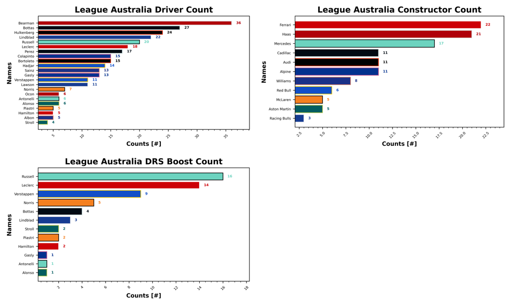

## Prizes

### Championship

| Prize Name | Prize Value | Terms | Manager | Team | Score |
| --- | --- | --- | --- | --- | --- |
|  | (%) |  |  |  |  |
| The World Champion | 20 | Awarded to the top scorer in the league at the end of the season |  |  |  |
| Nobody Remembers Who Came Second | 10 | Awarded to the second place scorer in the league at the end of the season |  |  |  |
| Hulkenberg Podium | 5 | Awarded to the third place scorer in the league at the end of the season |  |  |  |
| Below Par | 20 | Awarded to the lowest scorer in the league at the end of the season, commonly referred to as the Golf League |  |  |  |

### Regions

| Prize Name | Prize Value | Terms | Manager | Team | Score |
| --- | --- | --- | --- | --- | --- |
|  | (%) |  |  |  |  |
| Early Morning Starts | 4 | Awarded to the top scorer in the races in Asia [Australia, China, Japan, Bahrain, Saudi Arabia, Azerbaijan, Singapore, Qatar, and Abu Dhabi] |  |  |  |
| The Glits and Glam | 4 | Awarded to the top scorer in the races in America [Miami, Canada, USA, Mexico, Brazil, Las Vegas] |  |  |  |
| The Home of Motorsport | 4 | Awarded to the top scorer in the races in Europe [Monaco, Barcelona, Austria, Great Britain, Belgium, Hungary, Netherlands, Italy, Spain] |  |  |  |

### Races

[output not shown]

### Season

| Prize Name | Prize Value | Terms | Manager | Team(s) | Score |
| --- | --- | --- | --- | --- | --- |
|  | (%) |  |  |  |  |
| Manager of the Year | 3 | Highest manager points per value across all entered teams |  |  |  |
| Jackpot | 3 | Highest weekly score of the year |  |  |  |
| Bogie | 3 | Lowest weekly score of the year |  |  |  |
| Extra Mega DRS | 3 | Highest extra DRS token score |  |  |  |

## F1 Predict

Valerie takes the top step this week with a score of 130 points (50%) ahead of Val with 126 points (40%). Phil is in third with 89 points (40%) and Josh is in fourth with 77 points (50%). Stuart is in fifth place with 49 points (20%), and Matty rounds out the grid with 0 (0%).

## Next Up

Next up, China. The early mornings continue, and it's a sprint weekend! Good luck to you all.